# Evaluación Interactiva de Matemáticas ICFES

En una entrevista para una cadena de televisión, un piloto de un avión de acrobacias comenta en detalle cómo fue su presentación:

"Durante los primeros 35 segundos aumenté la altura de manera constante y luego, realicé una pirueta espectacular donde primero elevé el avión a una altura aún mayor y después descendí bruscamente. Esto duró 3 segundos, quedando a la mitad de la altura máxima inicial. Después de la pirueta, comencé a girar en torno al eje del avión durante 25 segundos, manteniendo la misma altura. Para finalizar, aterricé reduciendo la altura de manera constante durante 25 segundos".

¿Cuál de las siguientes gráficas representa de forma CORRECTA la información dada por el piloto?

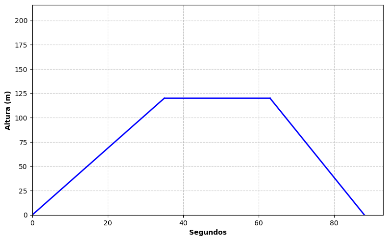

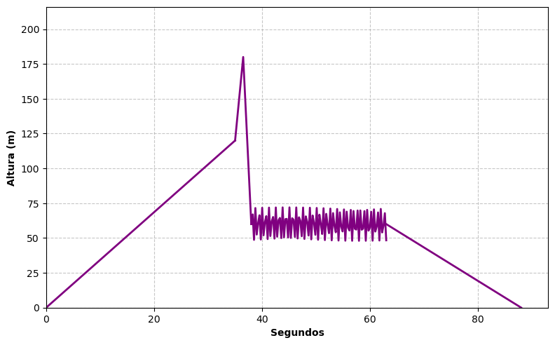

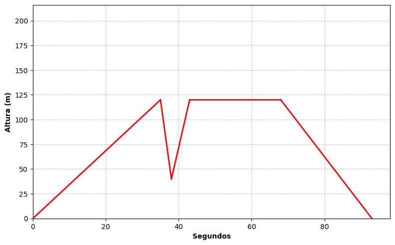

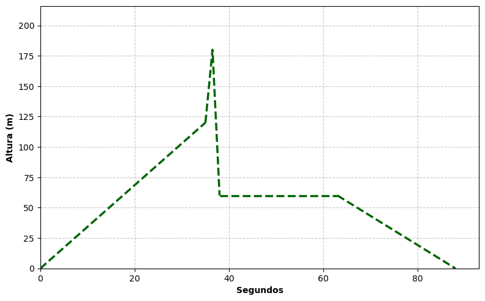

La gráfica correcta es la que representa adecuadamente las cuatro fases del vuelo acrobático descritas por el piloto:

1. Durante los primeros 35 segundos: aumento constante de altura (línea ascendente).
2. Pirueta espectacular donde primero elevó el avión a una altura mayor y después descendió bruscamente durante 3 segundos, quedando a la mitad de la altura máxima inicial (pico hacia arriba y luego descenso).
3. Giro alrededor del eje del avión durante 25 segundos manteniendo la misma altura (línea horizontal).
4. Aterrizaje con reducción constante de altura durante 25 segundos (línea descendente final).

Las demás opciones contienen elementos incorrectos que no corresponden con la descripción dada por el piloto. Estos errores pueden incluir:

- Mantener la altura constante después del ascenso inicial, sin mostrar la pirueta con el pico hacia arriba y el descenso.
- Mostrar solo un descenso constante durante la pirueta, sin el pico hacia arriba que el piloto describió.
- Incluir una fase adicional de elevación después de la pirueta, la cual no fue mencionada por el piloto.
- Mostrar la pirueta con un pico hacia arriba pero sin el descenso posterior, volviendo a la altura inicial.
- Mostrar oscilaciones durante la fase de giro, cuando el piloto especificó que mantuvo la misma altura.
- Presentar tiempos incorrectos en las diferentes fases del vuelo.

En una entrevista para una cadena de televisión, un piloto de un avión de acrobacias comenta en detalle cómo fue su presentación:

"Durante los primeros 25 segundos aumenté la altura de manera constante y luego, realicé una pirueta espectacular donde primero elevé el avión a una altura aún mayor y después descendí bruscamente. Esto duró 4 segundos, quedando a la mitad de la altura máxima inicial. Después de la pirueta, comencé a girar en torno al eje del avión durante 20 segundos, manteniendo la misma altura. Para finalizar, aterricé reduciendo la altura de manera constante durante 30 segundos".

¿Cuál de las siguientes gráficas representa de forma CORRECTA la información dada por el piloto?

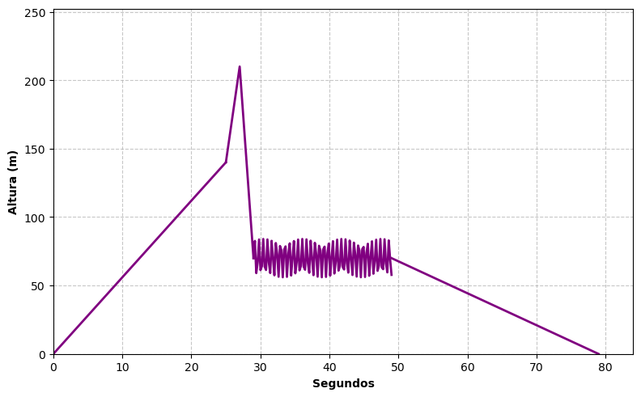

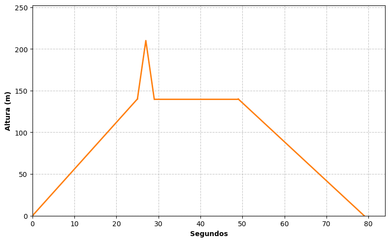

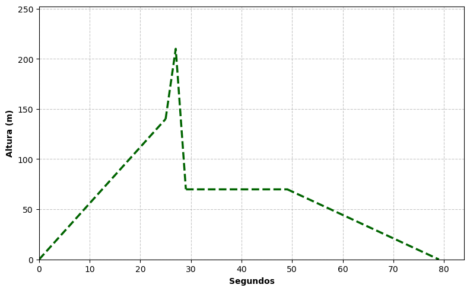

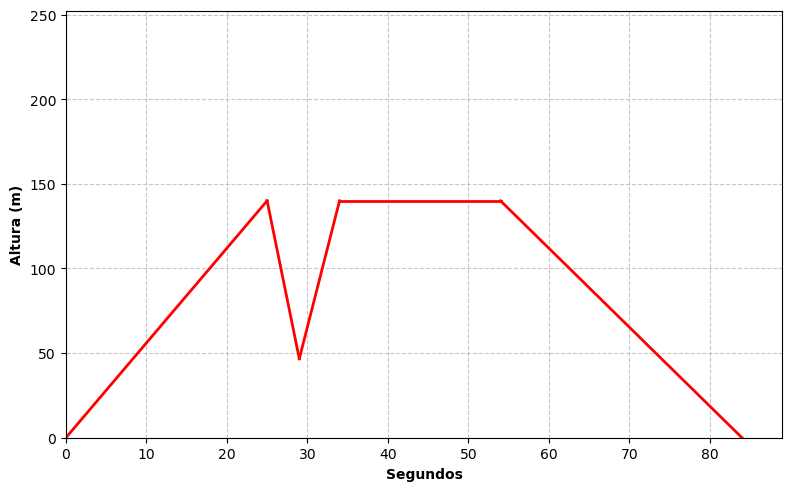

La gráfica correcta es la que representa adecuadamente las cuatro fases del vuelo acrobático descritas por el piloto:

1. Durante los primeros 25 segundos: aumento constante de altura (línea ascendente).
2. Pirueta espectacular donde primero elevó el avión a una altura mayor y después descendió bruscamente durante 4 segundos, quedando a la mitad de la altura máxima inicial (pico hacia arriba y luego descenso).
3. Giro alrededor del eje del avión durante 20 segundos manteniendo la misma altura (línea horizontal).
4. Aterrizaje con reducción constante de altura durante 30 segundos (línea descendente final).

Las demás opciones contienen elementos incorrectos que no corresponden con la descripción dada por el piloto. Estos errores pueden incluir:

- Mantener la altura constante después del ascenso inicial, sin mostrar la pirueta con el pico hacia arriba y el descenso.
- Mostrar solo un descenso constante durante la pirueta, sin el pico hacia arriba que el piloto describió.
- Incluir una fase adicional de elevación después de la pirueta, la cual no fue mencionada por el piloto.
- Mostrar la pirueta con un pico hacia arriba pero sin el descenso posterior, volviendo a la altura inicial.
- Mostrar oscilaciones durante la fase de giro, cuando el piloto especificó que mantuvo la misma altura.
- Presentar tiempos incorrectos en las diferentes fases del vuelo.